## Confidence Intervals

Confidence intervals are a very useful concept that is widely used by data scientists. A version of these that are very commonly seen come from the `ggplot` geometry `geom_smooth`. Here is an example using a temperature dataset available in R:

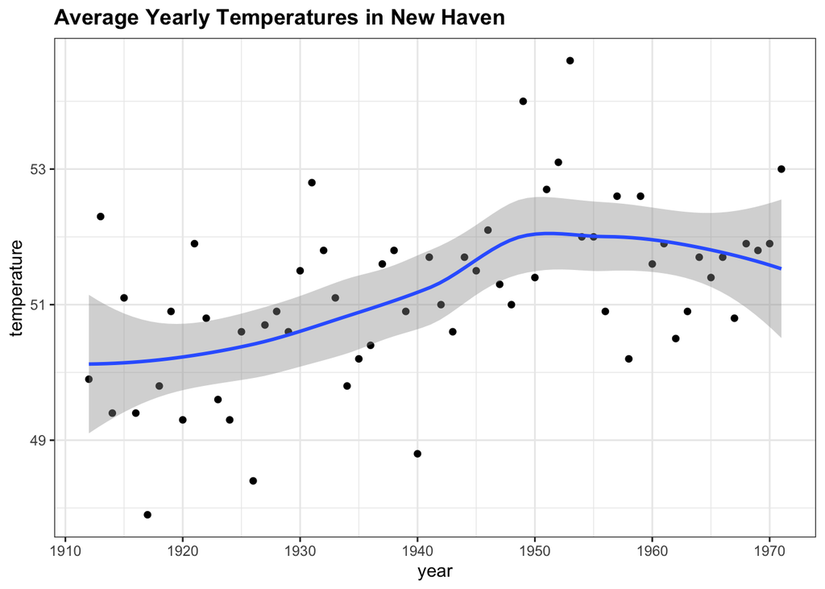

```r
data("nhtemp")
data.frame(year = as.numeric(time(nhtemp)), temperature=as.numeric(nhtemp)) %>%
  ggplot(aes(year, temperature)) +
  geom_point() +
  geom_smooth() +
  ggtitle("Average Yearly Temperatures in New Haven")
```

We will later learn how the curve is formed, but note the shaded area around the curve. The shaded area around the curve is created using the concept of confidence intervals.

When giving an estimate you are usually also asked to give an interval for this estimate. Suppose we have a group of pollsters who spend money sampling voters for their poll - like the class did with beads. Let’s also suppose the pollsters enter into a competition with two stages where they must produce an estimate for $p$ (the truth of the election) and an interval for their estimate of $p$. For the first stage, if the interval they submit includes $p$ they get half the money they spent on their “poll” back and pass to the next stage of the competition. One way to pass to the second round is to report a very large interval. For example, the interval $[0,1]$ is guaranteed to include $p$. However, with an interval this big, we have no chance of winning the competition. Similarly, if you are an election forecaster and predict the spread will be between -100% and 100% you will be ridiculed for stating the obvious. Even a smaller interval such as saying the spread will be between -10 and 10% will not be considered serious. Smaller intervals represent more confidence in an estimate.

On the other hand, the smaller the interval we report, the smaller our chances of winning the prize. Similarly, a bold pollster that reports very small intervals and misses the mark most of the time will not be considered a good pollster. We want to be somewhere in between.

We can use the statistical theory we have learned to compute the probability of any given interval including $p$. Similarly, if we are asked to create an interval with, say, a 95% chance of including $p$, we can do that as well. These are called 95% **confidence intervals**.

Note that when pollsters report an estimate and a margin of error, they are, in a way, reporting a 95% confidence interval. Let’s show how this works mathematically.

We want to know the probability that the interval $[\bar{X} - 2\hat{\mbox{SE}}(\bar{X}), \bar{X} + 2\hat{\mbox{SE}}(\bar{X})]$ contains the true proportion $p$. First, note that at the start and end of this interval are random variables: every time we take a sample they change. To illustrate this, let’s run a Monte Carlo simulation twice. Let’s use the parameters $p$ = 0.45 and $N = 1000$.

```r
p <- 0.45
N <- 1000
```

And note that the interval here

```r
X <- sample(c(0,1), size = N, replace = TRUE, prob = c(1-p, p))
X_hat <- mean(X)
SE_hat <- sqrt(X_hat*(1-X_hat)/N)
c(X_hat - 2*SE_hat, X_hat + 2*SE_hat)
```

```
## [1] 0.4523934 0.5156066
```

is different from this one:

```r
X <- sample(c(0,1), size = N, replace = TRUE, prob = c(1-p, p))
X_hat <- mean(X)
SE_hat <- sqrt(X_hat*(1-X_hat)/N)
c(X_hat - 2*SE_hat, X_hat + 2*SE_hat)
```

```
## [1] 0.4036456 0.4663544
```

Keep sampling and creating intervals and you will see the random variation.

To determine the probability that the interval includes $p$ we need to compute this:
$$\mbox{Pr}\left(\bar{X} - 2\hat{\mbox{SE}}(\bar{X}) \leq p \leq \bar{X} + 2\hat{\mbox{SE}}(\bar{X})\right)$$

By subtracting and dividing the same quantities in all parts of the equation we get that the above is equivalent to:

$$\mbox{Pr}\left(-2 \leq \frac{\bar{X}- p}{\hat{\mbox{SE}}(\bar{X})} \leq 2\right)$$

The term in the middle is an approximately normal random variable with expected value 0 and standard error 1, which we have been denoting with $Z$, so we have

$$\mbox{Pr}\left(-2 \leq Z \leq 2\right)$$

which we can quickly compute using

```r
pnorm(2) - pnorm(-2)
```

```
## [1] 0.9544997
```

proving the we have a 95% probability.

Note that if we want to have a larger probability, say 99%, we need to multiply by whatever `z` satisfies the following:

$$\mbox{Pr}\left(-z \leq Z \leq z\right) = 0.99$$

Note that by using

```r
z <- qnorm(0.995)
z
```

```
## [1] 2.575829
```

will do it because by definition `pnorm(qnorm(0.995))` is 0.995 and by symmetry `pnorm(1-qnorm(0.995))` is 1 - 0.995, and we have that

```r
pnorm(z)-pnorm(-z)
```

```
## [1] 0.99
```

is `0.995 - 0.005 = 0.99`. We can use this approach for any percentile $q$: we use $1 - (1 - q)/2$. Why this number? Because $1 - (1 - q)/2 + (1 - q)/2 = q$.

Note that to get an exactly 0.95 confidence interval, we actually use a slightly smaller number than 2:

```r
qnorm(0.975)
```

```
## [1] 1.959964
```

### A Monte Carlo Simulation

We can run a Monte Carlo simulation to confirm that in fact a 95% confidence interval includes $p$ 95% of the time.

```r
set.seed(1)
```

```r
B <- 10000
inside <- replicate(B, {
  X <- sample(c(0,1), size = N, replace = TRUE, prob = c(1-p, p))
  X_hat <- mean(X)
  SE_hat <- sqrt(X_hat*(1-X_hat)/N)
  between(p, X_hat - 1.96*SE_hat, X_hat + 1.96*SE_hat)
})
mean(inside)
```

```
## [1] 0.9473
```

The following plot shows the first 100 confidence intervals. The black line marks the true $p$, $p = 0.45$. In this case we see that 95 of the 100 intervals do include $p$.

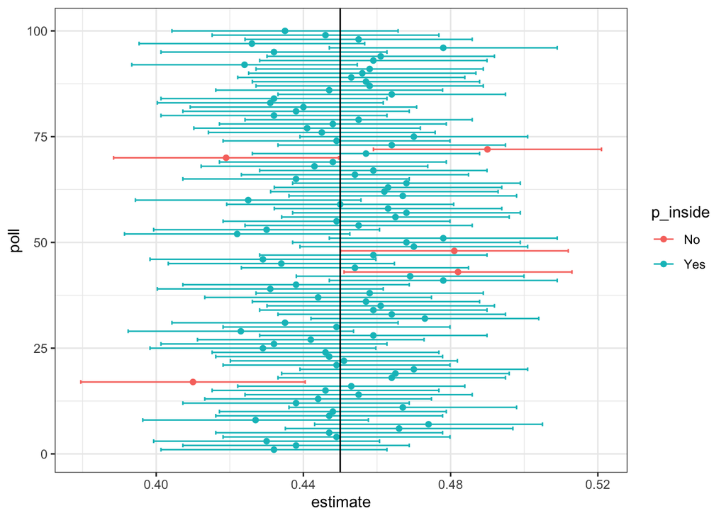

### The Correct Language

**When using the theory we described above it is important to remember that it is the intervals that are random, not $p$**. In the plot above we can see the random intervals moving around and $p$, represented with the vertical line, staying in the same place. So the 95% relates to the probability that this random interval falls on top of $p$. Saying the $p$ has a 95% chance of being between this and that is technically an incorrect statement. Again, because $p$ is not random.

### Power

Pollsters are not successful for providing correct confidence intervals but rather for predicting who will win. When we took a 25 bead sample size, the confidence interval for the spread:

```r
N <- 25
X_hat <- 0.48
(2*X_hat - 1) + c(-2,2)*2*sqrt(X_hat*(1-X_hat)/sqrt(N))
```

```
## [1] -0.9337114  0.8537114
```

includes 0. If this were a poll and we were forced to make a declaration, we would have to say it was a “toss-up”.

A problem with our poll results is that, given the sample size and the value of $p$, we would have to sacrifice on the probability of an incorrect call to create an interval that does not include 0.

**This does not mean that the election is close. It only means that we have a small sample size. In statistical textbooks this is called lack of *power*. In the context of polls, *power* is the probability of detecting spreads different from 0**.

By increasing our sample size, we lower our standard error and therefore have a much better chance of detecting the direction of the spread.

## p-values

p-values are ubiquitous in the scientific literature. They are related to confidence intervals so we introduce the concept here.

Let’s consider the blue and red beads. Suppose that rather than wanting an estimate of the spread or the proportion of blue, I am interested only in the question: are there more blue beads or red beads? I want to know if the spread $2p-1 > 0$, i.e. if $p > 0.5$ for one of the colors of beads.

Suppose we take a random sample of $N=100$ and we observe $52$ blue beads which gives us $2\bar{X}-1=0.04$. This seems to be pointing to there being more blue than red since 0.04 is larger than 0. However, as data scientists we need to be skeptical. We know there is chance involved in this process and we could get a 52 even when the actual spread is 0. We call this a *null hypothesis*. The null hypothesis is the skeptics hypothesis: the spread is $2p-1 = 0$, or $p = 0.5$. We have observed a random variable $\bar{X} = 0.52$ and the p-value is the answer to the question how likely is it to see a value this large or larger, when the null hypothesis is true. So we write

$$\mbox{Pr}(\mid 2\bar{X} - 1 \mid \geq 0.04 )$$
$$= \mbox{Pr}(\mid \bar{X} - 0.5 \mid \geq 0.02 )$$

assuming $2p-1=0$, or $p=0.5$. Under the null hypothesis we know that

$$\sqrt{N}\frac{\bar{X} - 0.5}{\sqrt{0.5(1-0.5)}}$$

is a standard normal random variable. So we can compute the probability above, which is the p-value.

$$\mbox{Pr}\left(\sqrt{N}\frac{\mid \bar{X} - 0.5\mid}{\sqrt{0.5(1-0.5)}} > \sqrt{N} \frac{0.02}{ \sqrt{0.5(1-0.5)}}\right)$$

```r
N = 100
z <- sqrt(N)*0.02/0.5
1 - (pnorm(z) - pnorm(-z))
```

```
## [1] 0.6891565
```

This is the p-value. In this case there is actually a large chance of seeing 52 or larger under the null hypothesis.

**Note that there is a close connection between p-values and confidence intervals. If a 95% confidence interval of the spread does not include 0, we know that the p-value must be smaller than 0.05**.

To learn more about p-values you can consult any statistcs textbook. However, in general we prefer reporting confidence intervals over p-values since it gives us an idea of the size of the estimate. The p-value simply reports a probability and says nothing about the significance of the finding in the context of the problem.